# CS 1675 Final Project: Part 4

Classification - Option A (metric: Accuracy)

Anastasia Sosnovskikh

## Load packages

Load the packages used for EDA.

```r
library(tidyverse)
```

```r
library(dplyr)
library(ggplot2)
library(caret)
library(coefplot)
```

## Load Data

Read in the data.

```r
data_url <- 'https://raw.githubusercontent.com/jyurko/CS_1675_Fall_2020/master/HW/final_project/cs_1675_final_project_data.csv'

df_raw <- readr::read_csv(data_url, col_names = TRUE)
```

Separate the variables associated with Step 1.

```r
df_step1_inputs <- df_raw %>% select(xA, xB, x01:x06, response_1)
```

Separate the variables associated with the Option B classification formulation. The `outcome_2` variable is converted to a factor with a specific ordering of the levels. This ordering is used when modeling in `caret` to make sure everyone predicts the `Fail` class as the “positive” class in the confusion matrix.

```r
df_step2_B_inputs <- df_raw %>% select(xA, xB, response_1, x07:x11, outcome_2) %>%
  mutate(outcome_2 = factor(outcome_2, levels = c('Fail', 'Pass')))
```

Separate the variables associated with the Option A classification formulation. The `outcome_2` variable is again converted to a factor with a specific ordering of the levels.

```r
df_step2_A_inputs <- df_raw %>% select(xA, xB, x01:x11, outcome_2) %>%
  mutate(outcome_2 = factor(outcome_2, levels = c('Fail', 'Pass')))
```

Change data types for the whole data frame to perform EDA.

```r
df <- df_raw %>%
  mutate(xA = as.factor(xA),
         xB = as.factor(xB),
         outcome_2 = factor(outcome_2, levels = c('Fail', 'Pass')))
```

Standardize the data.

```r
get_standardized <- function(df) {
  predict(preProcess(df, method = c('center', 'scale')), df)
}
```

## Fit Linear Models

### Set the variables

#### Input data set

Define a data set to train on.

```r
df_input <- df_step2_A_inputs
```

*We train classification on step 2A inputs*

#### Resampling Scheme

Define a resampling scheme.

```r
my_ctrl <- trainControl(method = 'repeatedcv',
                        number = 5,
                        repeats = 3,
                        classProbs = TRUE,
                        savePredictions = TRUE)
```

*I will use repeated cross-validation by specifying the number of repeats to be `3` and number of folds to be `5`. Thus, the models will be trained and tested a total of `15` times.*

#### Performance Metric

Define a primary performance metric.

```r
reg_metric <- 'Accuracy'
```

*Accuracy is used for this part of the project.*

#### Preprocessing scheme

Define pre-processing scheme.

```r
prep_scheme <- c('center', 'scale')
```

*I want to standardize the input.*

### Fitting the Models

#### Logistic regression with additive terms (method=‘glm’)

Provides a baseline comparison to the other models.

```r
set.seed(1234)
fit_glm <- train(outcome_2 ~ .,
                 data = df_input,
                 method = 'glm',
                 metric = reg_metric,
                 preProcess = prep_scheme,
                 trControl = my_ctrl)

fit_glm
```

```
## Generalized Linear Model
##
## 2013 samples
##   13 predictor
##    2 classes: 'Fail', 'Pass'
##
## Pre-processing: centered (15), scaled (15)
## Resampling: Cross-Validated (5 fold, repeated 3 times)
## Summary of sample sizes: 1611, 1610, 1610, 1611, 1610, 1610, ...
## Resampling results:
##
##   Accuracy   Kappa
##   0.5899831  0.1776712
```

#### Regularized regression with Elastic net (method=‘glmnet’)

Fit the model.

```r
set.seed(1234)
fit_elastic_add <- train(outcome_2 ~ .,
                         data = df_input,
                         method = 'glmnet',
                         metric = reg_metric,
                         preProcess = prep_scheme,
                         trControl = my_ctrl)

fit_elastic_add
```

```
## glmnet
##
## 2013 samples
##   13 predictor
##    2 classes: 'Fail', 'Pass'
##
## Pre-processing: centered (15), scaled (15)
## Resampling: Cross-Validated (5 fold, repeated 3 times)
## Summary of sample sizes: 1611, 1610, 1610, 1611, 1610, 1610, ...
## Resampling results across tuning parameters:
##
##   alpha  lambda       Accuracy   Kappa
##   0.10   0.000144654  0.5894880  0.1766032
##   0.10   0.001446540  0.5894880  0.1766032
##   0.10   0.014465400  0.5894868  0.1764994
##   0.55   0.000144654  0.5893210  0.1762623
##   0.55   0.001446540  0.5893210  0.1762623
##   0.55   0.014465400  0.5894856  0.1762455
##   1.00   0.000144654  0.5893206  0.1762377
##   1.00   0.001446540  0.5899831  0.1775116
##   1.00   0.014465400  0.5906431  0.1784335
##
## Accuracy was used to select the optimal model using the largest value.
## The final values used for the model were alpha = 1 and lambda = 0.0144654.
```

Print out the best tuning parameters.

```r
fit_elastic_add$bestTune
```

```
##   alpha    lambda
## 9     1 0.0144654
```

*This model favors Lasso.*

Consider all **pair** interactions between all of the input variables.

```r
set.seed(1234)
fit_elastic_pairs <- train(outcome_2 ~ (.)^2,
                    data = df_input,
                    method = 'glmnet',
                    metric = reg_metric,
                    preProcess = prep_scheme,
                    trControl = my_ctrl)

fit_elastic_pairs
```

```
## glmnet
##
## 2013 samples
##   13 predictor
##    2 classes: 'Fail', 'Pass'
##
## Pre-processing: centered (117), scaled (117)
## Resampling: Cross-Validated (5 fold, repeated 3 times)
## Summary of sample sizes: 1611, 1610, 1610, 1611, 1610, 1610, ...
## Resampling results across tuning parameters:
##
##   alpha  lambda        Accuracy   Kappa
##   0.10   0.0001455549  0.5995889  0.1972476
##   0.10   0.0014555489  0.5918044  0.1814218
##   0.10   0.0145554894  0.5908094  0.1792645
##   0.55   0.0001455549  0.5954516  0.1890181
##   0.55   0.0014555489  0.5914723  0.1806846
##   0.55   0.0145554894  0.5903152  0.1780763
##   1.00   0.0001455549  0.5957858  0.1896845
##   1.00   0.0014555489  0.5911415  0.1800210
##   1.00   0.0145554894  0.5918015  0.1809998
##
## Accuracy was used to select the optimal model using the largest value.
## The final values used for the model were alpha = 0.1 and lambda = 0.0001455549.
```

Print out the best tuning parameters.

```r
fit_elastic_pairs$bestTune
```

```
##   alpha       lambda
## 1   0.1 0.0001455549
```

*This model favor Ridge.*

Check the number of coefficients that must be learned.

```r
fit_elastic_pairs$coefnames %>% length()
```

```
## [1] 117
```

Consider all **triplet** interactions between all of the input variables.

```r
set.seed(1234)
fit_elastic_triplets <- train(outcome_2 ~ (.)^3,
                    data = df_input,
                    method = 'glmnet',
                    metric = reg_metric,
                    preProcess = prep_scheme,
                    trControl = my_ctrl)

fit_elastic_triplets
```

```
## glmnet
##
## 2013 samples
##   13 predictor
##    2 classes: 'Fail', 'Pass'
##
## Pre-processing: centered (535), scaled (535)
## Resampling: Cross-Validated (5 fold, repeated 3 times)
## Summary of sample sizes: 1611, 1610, 1610, 1611, 1610, 1610, ...
## Resampling results across tuning parameters:
##
##   alpha  lambda        Accuracy   Kappa
##   0.10   0.0001460282  0.6095359  0.2182120
##   0.10   0.0014602822  0.5951187  0.1883129
##   0.10   0.0146028219  0.5906436  0.1789955
##   0.55   0.0001460282  0.6075499  0.2142050
##   0.55   0.0014602822  0.5929636  0.1837189
##   0.55   0.0146028219  0.5888239  0.1750927
##   1.00   0.0001460282  0.6002568  0.1992876
##   1.00   0.0014602822  0.5903144  0.1783344
##   1.00   0.0146028219  0.5883288  0.1740133
##
## Accuracy was used to select the optimal model using the largest value.
## The final values used for the model were alpha = 0.1 and lambda = 0.0001460282.
```

Print out the best tuning parameters.

```r
fit_elastic_triplets$bestTune
```

```
##   alpha       lambda
## 1   0.1 0.0001460282
```

*This model favors Ridge.*

Check the number of coefficients that must be learned.

```r
fit_elastic_triplets$coefnames %>% length()
```

```
## [1] 535
```

#### Neural network

Train the standard Neural Network.

```r
set.seed(1234)
fit_nnet <- train(outcome_2 ~ .,
                  data = df_input,
                  method = 'nnet',
                  metric = reg_metric,
                  preProcess = prep_scheme,
                  trControl = my_ctrl,
                  trace = FALSE)

fit_nnet
```

```
## Neural Network
##
## 2013 samples
##   13 predictor
##    2 classes: 'Fail', 'Pass'
##
## Pre-processing: centered (15), scaled (15)
## Resampling: Cross-Validated (5 fold, repeated 3 times)
## Summary of sample sizes: 1611, 1610, 1610, 1611, 1610, 1610, ...
## Resampling results across tuning parameters:
##
##   size  decay  Accuracy   Kappa
##   1     0e+00  0.5885095  0.1678083
##   1     1e-04  0.5971149  0.1862451
##   1     1e-01  0.6149797  0.2245007
##   3     0e+00  0.6333839  0.2659677
##   3     1e-04  0.6307244  0.2610707
##   3     1e-01  0.6830525  0.3657454
##   5     0e+00  0.6418211  0.2825085
##   5     1e-04  0.6305602  0.2608019
##   5     1e-01  0.6764490  0.3523462
##
## Accuracy was used to select the optimal model using the largest value.
## The final values used for the model were size = 3 and decay = 0.1.
```

Print out the best tuning parameters.

```r
fit_nnet$bestTune
```

```
##   size decay
## 6    3   0.1
```

Tune the Neural Network.

`size` is the number of units in hidden layer (`nnet` fit a single hidden layer neural network) and `decay` is the regularization parameter to avoid over-fitting.

```r
set.seed(1234)
nnet_grid <- expand.grid(size = seq(from = 1, to = 10, by = 1),
                         decay = c(1e-4, 0.1, 0.5))

fit_nnet_tuned <- train(outcome_2 ~ .,
                  data = df_input,
                  tuneGrid = nnet_grid,
                  method = 'nnet',
                  metric = reg_metric,
                  preProcess = prep_scheme,
                  trControl = my_ctrl,
                  trace = FALSE)

fit_nnet_tuned
```

```
## Neural Network
##
## 2013 samples
##   13 predictor
##    2 classes: 'Fail', 'Pass'
##
## Pre-processing: centered (15), scaled (15)
## Resampling: Cross-Validated (5 fold, repeated 3 times)
## Summary of sample sizes: 1611, 1610, 1610, 1611, 1610, 1610, ...
## Resampling results across tuning parameters:
##
##   size  decay  Accuracy   Kappa
##    1    1e-04  0.5971137  0.1867055
##    1    1e-01  0.6103445  0.2149297
##    1    5e-01  0.6050513  0.2054232
```

[output cut: 30 more lines]

Print out the best tuning parameters.

```r
fit_nnet_tuned$bestTune
```

```
##    size decay
## 24    8   0.5
```

#### Random forest (RF)

The random forest model creates `500` bagged tree models. Compared to a standard bagged tree model, the random forest randomly selects the number of features to consider during the splitting process.

Train the standard Random Forest.

```r
set.seed(1234)
fit_rf <- train(outcome_2 ~ .,
                data = df_input,
                method = 'rf',
                metric = reg_metric,
                trControl = my_ctrl,
                importance = TRUE)

fit_rf
```

```
## Random Forest
##
## 2013 samples
##   13 predictor
##    2 classes: 'Fail', 'Pass'
##
## No pre-processing
## Resampling: Cross-Validated (5 fold, repeated 3 times)
## Summary of sample sizes: 1611, 1610, 1610, 1611, 1610, 1610, ...
## Resampling results across tuning parameters:
##
##   mtry  Accuracy   Kappa
##    2    0.7229539  0.4455555
##    8    0.7347226  0.4698755
##   15    0.7271060  0.4544881
##
## Accuracy was used to select the optimal model using the largest value.
## The final value used for the model was mtry = 8.
```

Print out the best tuning parameters.

```r
fit_rf$bestTune
```

```
##   mtry
## 2    8
```

Tune the Random Forest.

`mtry` is number of predictors sampled for splitting at each node.

```r
set.seed(1234)
rf_grid <- expand.grid(mtry = seq(from = 1, to = 10, by = 1))

fit_rf_tuned <- train(outcome_2 ~ .,
                data = df_input,
                tuneGrid = rf_grid,
                method = 'rf',
                metric = reg_metric,
                trControl = my_ctrl,
                importance = TRUE)

fit_rf_tuned
```

```
## Random Forest
##
## 2013 samples
##   13 predictor
##    2 classes: 'Fail', 'Pass'
##
## No pre-processing
## Resampling: Cross-Validated (5 fold, repeated 3 times)
## Summary of sample sizes: 1611, 1610, 1610, 1611, 1610, 1610, ...
## Resampling results across tuning parameters:
##
##   mtry  Accuracy   Kappa
##    1    0.6590530  0.3130681
##    2    0.7204704  0.4407047
##    3    0.7348728  0.4699305
##    4    0.7355415  0.4714484
##    5    0.7380286  0.4764668
##    6    0.7348855  0.4701861
##    7    0.7380315  0.4765603
##    8    0.7322350  0.4648577
##    9    0.7347197  0.4698511
##   10    0.7315758  0.4635833
##
## Accuracy was used to select the optimal model using the largest value.
## The final value used for the model was mtry = 7.
```

Print out the best tuning parameters.

```r
fit_rf_tuned$bestTune
```

```
##   mtry
## 7    7
```

#### Gradient boosted tree

Fit the Gradient Boosted Tree.

```r
set.seed(1234)
fit_xgb <- train(outcome_2 ~ .,
                data = df_input,
                method = 'xgbTree',
                metric = reg_metric,
                trControl = my_ctrl)

fit_xgb
```

```
## eXtreme Gradient Boosting
##
## 2013 samples
##   13 predictor
##    2 classes: 'Fail', 'Pass'
##
## No pre-processing
## Resampling: Cross-Validated (5 fold, repeated 3 times)
## Summary of sample sizes: 1611, 1610, 1610, 1611, 1610, 1610, ...
## Resampling results across tuning parameters:
##
##   eta  max_depth  colsample_bytree  subsample  nrounds  Accuracy   Kappa
##   0.3  1          0.6               0.50        50      0.7069002  0.4124660
##   0.3  1          0.6               0.50       100      0.7143526  0.4275120
##   0.3  1          0.6               0.50       150      0.7107033  0.4203892
##   0.3  1          0.6               0.75        50      0.7097103  0.4179205
##   0.3  1          0.6               0.75       100      0.7204762  0.4398837
##   0.3  1          0.6               0.75       150      0.7213033  0.4416532
##   0.3  1          0.6               1.00        50      0.7074010  0.4131370
##   0.3  1          0.6               1.00       100      0.7171594  0.4329686
##   0.3  1          0.6               1.00       150      0.7222971  0.4434206
##   0.3  1          0.8               0.50        50      0.7062397  0.4111695
##   0.3  1          0.8               0.50       100      0.7116946  0.4223918
##   0.3  1          0.8               0.50       150      0.7057323  0.4106047
##   0.3  1          0.8               0.75        50      0.7050846  0.4085493
##   0.3  1          0.8               0.75       100      0.7117049  0.4222477
##   0.3  1          0.8               0.75       150      0.7131933  0.4253616
##   0.3  1          0.8               1.00        50      0.7054134  0.4091736
##   0.3  1          0.8               1.00       100      0.7189845  0.4366003
##   0.3  1          0.8               1.00       150      0.7188182  0.4364143
##   0.3  2          0.6               0.50        50      0.7126979  0.4244095
##   0.3  2          0.6               0.50       100      0.7077318  0.4146389
##   0.3  2          0.6               0.50       150      0.7019341  0.4031396
##   0.3  2          0.6               0.75        50      0.7223025  0.4437218
##   0.3  2          0.6               0.75       100      0.7191511  0.4374262
##   0.3  2          0.6               0.75       150      0.7188199  0.4370303
##   0.3  2          0.6               1.00        50      0.7227946  0.4446092
##   0.3  2          0.6               1.00       100      0.7184899  0.4360429
##   0.3  2          0.6               1.00       150      0.7189894  0.4370526
##   0.3  2          0.8               0.50        50      0.7123621  0.4238184
```

[output cut: 73 more lines]

```
##   0.4  3          0.8               0.50       150      0.6871980  0.3741765
##   0.4  3          0.8               0.75        50      0.7171664  0.4336992
##   0.4  3          0.8               0.75       100      0.7057405  0.4109754
##   0.4  3          0.8               0.75       150      0.6977951  0.3949601
##   0.4  3          0.8               1.00        50      0.7158385  0.4308970
##   0.4  3          0.8               1.00       100      0.7151789  0.4296932
##   0.4  3          0.8               1.00       150      0.7115415  0.4224127
##
## Tuning parameter 'gamma' was held constant at a value of 0
## Tuning
##  parameter 'min_child_weight' was held constant at a value of 1
## Accuracy was used to select the optimal model using the largest value.
## The final values used for the model were nrounds = 50, max_depth = 3, eta
##  = 0.3, gamma = 0, colsample_bytree = 0.8, min_child_weight = 1 and subsample
##  = 1.
```

Print out the best tuning parameters.

```r
fit_xgb$bestTune
```

```
##    nrounds max_depth eta gamma colsample_bytree min_child_weight subsample
## 52      50         3 0.3     0              0.8                1         1
```

Plot the cross-validation results.

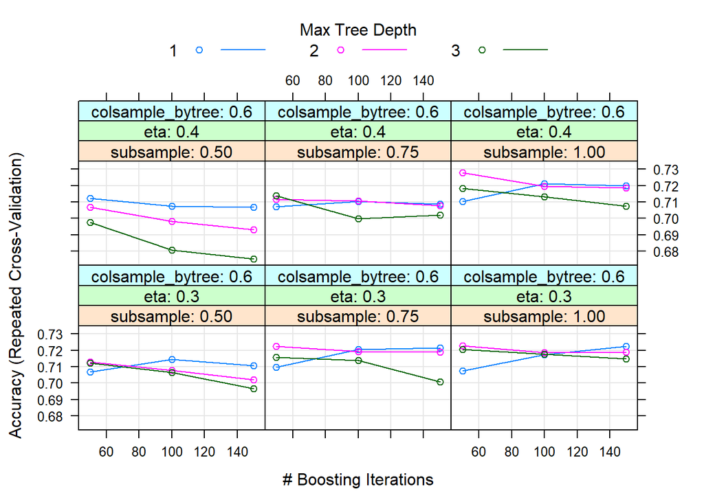

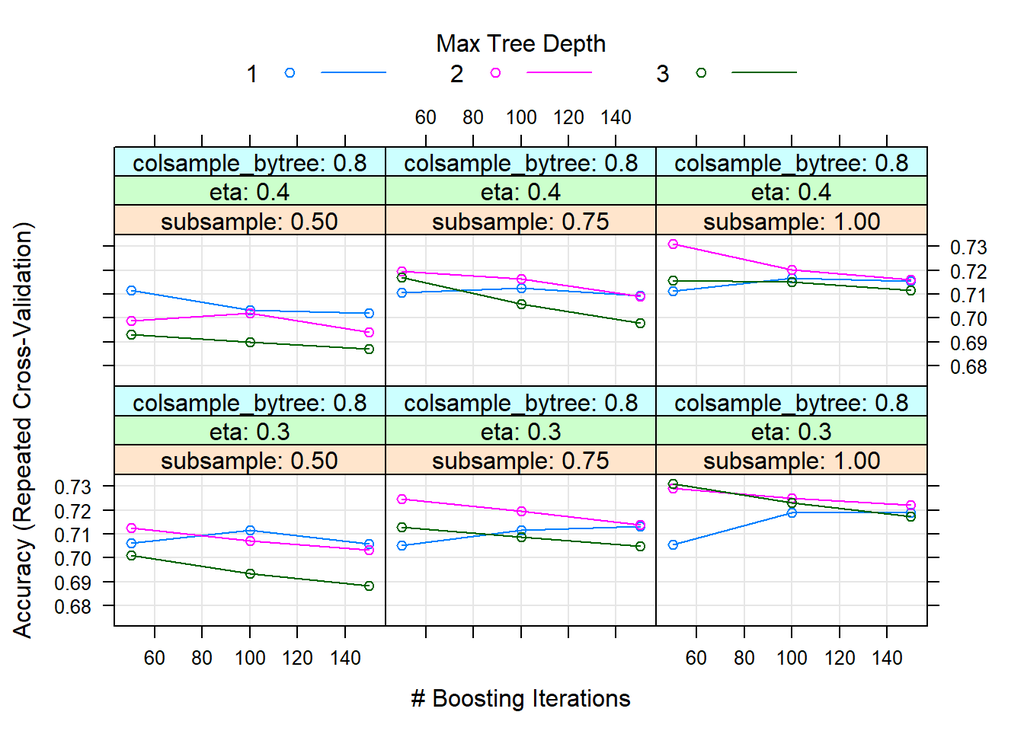

```r
fit_xgb %>% plot()
```

Tune the Gradient Booster Tree model.

- `nrounds` controls the maximum number of iterations. For classification, it is similar to the number of trees to grow.
- `eta` controls the learning rate, i.e., the rate at which our model learns patterns in data. After every round, it shrinks the feature weights to reach the best optimum. Lower eta leads to slower computation. It must be supported by increase in `nrounds`.
- `max_depth` controls the depth of the tree.
- `gamma` controls regularization (or prevents overfitting). Higher the value, higher the regularization. Regularization means penalizing large coefficients which don’t improve the model’s performance. The default is 0 which means no regularization.
- `colsample_bytree` controls the number of features (variables) supplied to a tree. Typically, its values lie between (0.5,0.9).
- `min_child_weight`, in regression, it refers to the minimum number of instances required in a child node. In classification, if the leaf node has a minimum sum of instance weight (calculated by second order partial derivative) lower than min_child_weight, the tree splitting stops. In other words, it blocks the potential feature interactions to prevent overfitting.
- `subsample` controls the number of samples (observations) supplied to a tree. Typically, its values lie between (0.5-0.8).

I will hold all the parameters constant except for `nrounds`, `max_depth`, and `eta`.

```r
set.seed(1234)
xgb_grid <- expand.grid(nrounds = seq(from = 10, to = 50, by = 10),
                        max_depth = seq(from = 1, to = 6, by = 1),
                        eta = seq(from = 0.1, to = 0.8, by = 0.1),
                        gamma = 0,
                        colsample_bytree = 0.8,
                        min_child_weight = 1,
                        subsample = 1)

fit_xgb_tuned <- train(outcome_2 ~ .,
                      data = df_input,
                       tuneGrid = xgb_grid,
                       method = 'xgbTree',
                       metric = reg_metric,
                       trControl = my_ctrl)

fit_xgb_tuned
```

```
## eXtreme Gradient Boosting
##
## 2013 samples
##   13 predictor
##    2 classes: 'Fail', 'Pass'
##
## No pre-processing
## Resampling: Cross-Validated (5 fold, repeated 3 times)
## Summary of sample sizes: 1611, 1610, 1610, 1611, 1610, 1610, ...
## Resampling results across tuning parameters:
##
##   eta  max_depth  nrounds  Accuracy   Kappa
##   0.1  1          10       0.6188141  0.2310605
##   0.1  1          20       0.6476221  0.2902525
##   0.1  1          30       0.6621989  0.3199662
##   0.1  1          40       0.6729673  0.3420509
##   0.1  1          50       0.6825632  0.3617927
##   0.1  2          10       0.6582209  0.3125661
##   0.1  2          20       0.6858750  0.3686934
##   0.1  2          30       0.6974589  0.3925685
##   0.1  2          40       0.7072347  0.4124307
##   0.1  2          50       0.7126975  0.4237355
##   0.1  3          10       0.6871992  0.3720727
##   0.1  3          20       0.7095515  0.4173165
##   0.1  3          30       0.7171718  0.4330096
##   0.1  3          40       0.7232975  0.4454747
##   0.1  3          50       0.7272644  0.4536715
##   0.1  4          10       0.7016024  0.4019063
##   0.1  4          20       0.7247876  0.4484904
##   0.1  4          30       0.7322379  0.4636067
##   0.1  4          40       0.7365427  0.4723097
##   0.1  4          50       0.7393541  0.4779767
##   0.1  5          10       0.7107087  0.4203016
##   0.1  5          20       0.7256122  0.4503649
##   0.1  5          30       0.7350493  0.4694119
##   0.1  5          40       0.7357155  0.4707580
##   0.1  5          50       0.7337288  0.4668348
##   0.1  6          10       0.7097177  0.4186230
##   0.1  6          20       0.7206466  0.4406727
##   0.1  6          30       0.7270998  0.4536450
```

[output cut: 208 more lines]

```
##   0.8  6          20       0.6933175  0.3860704
##   0.8  6          30       0.6954775  0.3903878
##   0.8  6          40       0.6994498  0.3983173
##   0.8  6          50       0.6931607  0.3856625
##
## Tuning parameter 'gamma' was held constant at a value of 0
## Tuning
##
## Tuning parameter 'min_child_weight' was held constant at a value of 1
##
## Tuning parameter 'subsample' was held constant at a value of 1
## Accuracy was used to select the optimal model using the largest value.
## The final values used for the model were nrounds = 50, max_depth = 4, eta
##  = 0.1, gamma = 0, colsample_bytree = 0.8, min_child_weight = 1 and subsample
##  = 1.
```

Print out the best tuning parameters.

```r
fit_xgb_tuned$bestTune
```

```
##    nrounds max_depth eta gamma colsample_bytree min_child_weight subsample
## 20      50         4 0.1     0              0.8                1         1
```

Plot the cross-validation results.

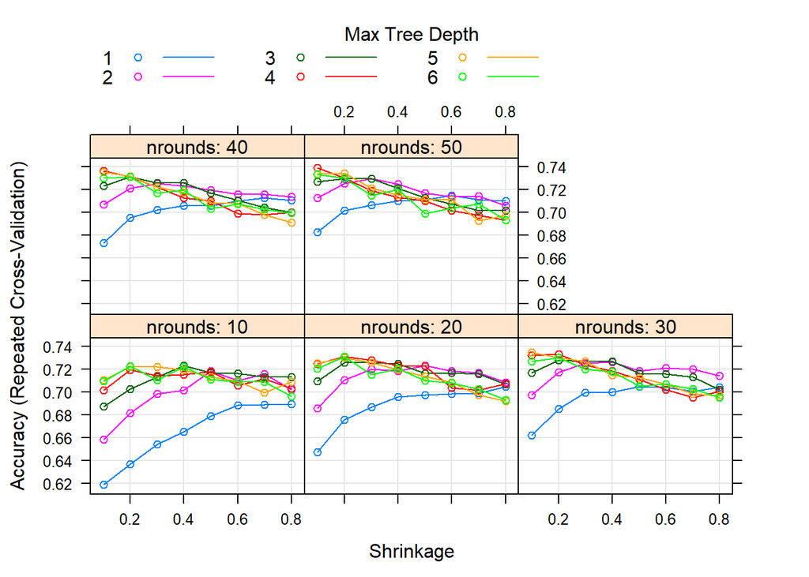

```r
fit_xgb_tuned %>% plot()
```

#### Support Vector Machine (SVM)

Fit the Support Vector Machine.

```r
set.seed(1234)
fit_svm <- train(outcome_2 ~ .,
                data = df_input,
                 method = 'svmRadial',
                 metric = reg_metric,
                 preProcess = prep_scheme,
                 trControl = my_ctrl)

fit_svm
```

```
## Support Vector Machines with Radial Basis Function Kernel
##
## 2013 samples
##   13 predictor
##    2 classes: 'Fail', 'Pass'
##
## Pre-processing: centered (15), scaled (15)
## Resampling: Cross-Validated (5 fold, repeated 3 times)
## Summary of sample sizes: 1611, 1610, 1610, 1611, 1610, 1610, ...
## Resampling results across tuning parameters:
##
##   C     Accuracy   Kappa
##   0.25  0.6587200  0.3165661
##   0.50  0.6769321  0.3528385
##   1.00  0.6923332  0.3835599
##
## Tuning parameter 'sigma' was held constant at a value of 0.04112442
## Accuracy was used to select the optimal model using the largest value.
## The final values used for the model were sigma = 0.04112442 and C = 1.
```

Print out the best tuning parameters.

```r
fit_svm$bestTune
```

```
##        sigma C
## 3 0.04112442 1
```

Tune the Support Vector Machine.

`C` is a regularization parameter that controls the trade off between a low training error and a low testing error (generalizability).

`sigma` (or sometimes `gamma`) parameter defines how far the influence of a single training example reaches, with low values meaning ‘far’ and high values meaning ‘close’.

```r
set.seed(1234)
svm_grid <- expand.grid(C = seq(from = 0.1, to = 2, by = 0.2),
                        sigma = seq(from = 0.01, to = 0.1, by = 0.02))

fit_svm_tuned <- train(outcome_2 ~ .,
                data = df_input,
                 tuneGrid = svm_grid,
                 method = 'svmRadial',
                 metric = reg_metric,
                 preProcess = prep_scheme,
                 trControl = my_ctrl)

fit_svm_tuned
```

```
## Support Vector Machines with Radial Basis Function Kernel
##
## 2013 samples
##   13 predictor
##    2 classes: 'Fail', 'Pass'
##
## Pre-processing: centered (15), scaled (15)
## Resampling: Cross-Validated (5 fold, repeated 3 times)
## Summary of sample sizes: 1611, 1610, 1610, 1611, 1610, 1610, ...
## Resampling results across tuning parameters:
##
##   C    sigma  Accuracy   Kappa
##   0.1  0.01   0.6040723  0.2083701
##   0.1  0.03   0.6332082  0.2644961
##   0.1  0.05   0.6434807  0.2858959
##   0.1  0.07   0.6509331  0.3014284
##   0.1  0.09   0.6545782  0.3090954
##   0.3  0.01   0.6181380  0.2333814
##   0.3  0.03   0.6517606  0.3024411
##   0.3  0.05   0.6716307  0.3424943
##   0.3  0.07   0.6777605  0.3549604
##   0.3  0.09   0.6795826  0.3588871
##   0.5  0.01   0.6270813  0.2516454
##   0.5  0.03   0.6648437  0.3284873
##   0.5  0.05   0.6814040  0.3619573
##   0.5  0.07   0.6862075  0.3717386
##   0.5  0.09   0.6872001  0.3739865
##   0.7  0.01   0.6342037  0.2662812
##   0.7  0.03   0.6741162  0.3470055
##   0.7  0.05   0.6920007  0.3829651
##   0.7  0.07   0.6921702  0.3836524
##   0.7  0.09   0.6936574  0.3869279
##   0.9  0.01   0.6390068  0.2760088
##   0.9  0.03   0.6842187  0.3672026
##   0.9  0.05   0.6928303  0.3847041
##   0.9  0.07   0.6946504  0.3886936
##   0.9  0.09   0.6943204  0.3883762
##   1.1  0.01   0.6439774  0.2861623
##   1.1  0.03   0.6868659  0.3725058
##   1.1  0.05   0.6941525  0.3873666
```

[output cut: 10 more lines]

```
##   1.5  0.07   0.6989523  0.3973031
##   1.5  0.09   0.6969668  0.3933509
##   1.7  0.01   0.6525878  0.3034200
##   1.7  0.03   0.6938216  0.3863054
##   1.7  0.05   0.7016016  0.4022361
##   1.7  0.07   0.7001123  0.3994868
##   1.7  0.09   0.6949796  0.3893697
##   1.9  0.01   0.6572246  0.3127787
##   1.9  0.03   0.6919995  0.3827197
##   1.9  0.05   0.7020979  0.4033136
##   1.9  0.07   0.6997803  0.3988222
##   1.9  0.09   0.6982922  0.3959340
##
## Accuracy was used to select the optimal model using the largest value.
## The final values used for the model were sigma = 0.05 and C = 1.9.
```

Print out the best tuning parameters.

```r
fit_svm_tuned$bestTune
```

```
##    sigma   C
## 48  0.05 1.9
```

#### Partial Least Squares (PLS)

Fit the Partial Least Squares.

```r
set.seed(1234)
fit_pls <- train(outcome_2 ~ .,
                data = df_input,
                 method = 'pls',
                 metric = reg_metric,
                 preProcess = prep_scheme,
                 trControl = my_ctrl)

fit_pls
```

```
## Partial Least Squares
##
## 2013 samples
##   13 predictor
##    2 classes: 'Fail', 'Pass'
##
## Pre-processing: centered (15), scaled (15)
## Resampling: Cross-Validated (5 fold, repeated 3 times)
## Summary of sample sizes: 1611, 1610, 1610, 1611, 1610, 1610, ...
## Resampling results across tuning parameters:
##
##   ncomp  Accuracy   Kappa
##   1      0.5870030  0.1728566
##   2      0.5909781  0.1795998
##   3      0.5899868  0.1777330
##
## Accuracy was used to select the optimal model using the largest value.
## The final value used for the model was ncomp = 2.
```

Print out the best tuning parameters.

```r
fit_pls$bestTune
```

```
##   ncomp
## 2     2
```

Tune the Partial Least Squares.

`ncomp` is the number of components to fit on.

```r
set.seed(1234)
pls_grid <- expand.grid(ncomp = seq(from = 1, to = 7, by = 1))

fit_pls_tuned <- train(outcome_2 ~ .,
                data = df_input,
                       tuneGrid = pls_grid,
                       method = 'pls',
                       metric = reg_metric,
                       preProcess = prep_scheme,
                       trControl = my_ctrl)

fit_pls_tuned
```

```
## Partial Least Squares
##
## 2013 samples
##   13 predictor
##    2 classes: 'Fail', 'Pass'
##
## Pre-processing: centered (15), scaled (15)
## Resampling: Cross-Validated (5 fold, repeated 3 times)
## Summary of sample sizes: 1611, 1610, 1610, 1611, 1610, 1610, ...
## Resampling results across tuning parameters:
##
##   ncomp  Accuracy   Kappa
##   1      0.5870030  0.1728566
##   2      0.5909781  0.1795998
##   3      0.5899868  0.1777330
##   4      0.5904843  0.1786427
##   5      0.5893226  0.1762524
##   6      0.5889909  0.1756233
##   7      0.5889909  0.1756233
##
## Accuracy was used to select the optimal model using the largest value.
## The final value used for the model was ncomp = 2.
```

Print out the best tuning parameters.

```r
fit_pls_tuned$bestTune
```

```
##   ncomp
## 2     2
```

*Since Partial Least Squares are used for the problems with correlated inputs, the above models did not perform well. Thus, I want to try using interactions as well.*

Fit the Partial Least Squares.

```r
set.seed(1234)
fit_pls_pair <- train(outcome_2 ~ (.)^2,
                 data = df_input,
                 method = 'pls',
                 metric = reg_metric,
                 preProcess = prep_scheme,
                 trControl = my_ctrl)

fit_pls_pair
```

```
## Partial Least Squares
##
## 2013 samples
##   13 predictor
##    2 classes: 'Fail', 'Pass'
##
## Pre-processing: centered (117), scaled (117)
## Resampling: Cross-Validated (5 fold, repeated 3 times)
## Summary of sample sizes: 1611, 1610, 1610, 1611, 1610, 1610, ...
## Resampling results across tuning parameters:
##
##   ncomp  Accuracy   Kappa
##   1      0.5891576  0.1757959
##   2      0.5924719  0.1826743
##   3      0.5906506  0.1788714
##
## Accuracy was used to select the optimal model using the largest value.
## The final value used for the model was ncomp = 2.
```

Print out the best tuning parameters.

```r
fit_pls_pair$bestTune
```

```
##   ncomp
## 2     2
```

Tune the Partial Least Squares.

```r
set.seed(1234)
pls_grid <- expand.grid(ncomp = seq(from = 1, to = 10, by = 1))

fit_pls_pair_tuned <- train(outcome_2 ~ (.)^2,
                       data = df_input,
                       tuneGrid = pls_grid,
                       method = 'pls',
                       metric = reg_metric,
                       preProcess = prep_scheme,
                       trControl = my_ctrl)

fit_pls_pair_tuned
```

```
## Partial Least Squares
##
## 2013 samples
##   13 predictor
##    2 classes: 'Fail', 'Pass'
##
## Pre-processing: centered (117), scaled (117)
## Resampling: Cross-Validated (5 fold, repeated 3 times)
## Summary of sample sizes: 1611, 1610, 1610, 1611, 1610, 1610, ...
## Resampling results across tuning parameters:
##
##   ncomp  Accuracy   Kappa
##    1     0.5891576  0.1757959
##    2     0.5924719  0.1826743
##    3     0.5906506  0.1788714
##    4     0.5916382  0.1810642
##    5     0.5874968  0.1726219
##    6     0.5886584  0.1748888
##    7     0.5878313  0.1733264
##    8     0.5893210  0.1763771
##    9     0.5894839  0.1766409
##   10     0.5908102  0.1792882
##
## Accuracy was used to select the optimal model using the largest value.
## The final value used for the model was ncomp = 2.
```

Print out the best tuning parameters.

```r
fit_pls_pair_tuned$bestTune
```

```
##   ncomp
## 2     2
```

*The performance did NOT improve. PLS is not a good model to use for this problem because the inputs are uncorrelated.*

#### Generalized Additive Models (GAM)

*Since PLS is not suited for this problem because the inputs are not correlated, I wanted to try GAM as well.*

Fit the Generalized Additive Model.

```r
set.seed(1234)
fit_gam <- train(outcome_2 ~ .,
                 data = df_input,
                 method = 'gam',
                 metric = reg_metric,
                 preProcess = prep_scheme,
                 trControl = my_ctrl)
fit_gam
```

```
## Generalized Additive Model using Splines
##
## 2013 samples
##   13 predictor
##    2 classes: 'Fail', 'Pass'
##
## Pre-processing: centered (15), scaled (15)
## Resampling: Cross-Validated (5 fold, repeated 3 times)
## Summary of sample sizes: 1611, 1610, 1610, 1611, 1610, 1610, ...
## Resampling results across tuning parameters:
##
##   select  Accuracy   Kappa
##   FALSE   0.7252768  0.4496526
##    TRUE   0.7261073  0.4513315
##
## Tuning parameter 'method' was held constant at a value of GCV.Cp
## Accuracy was used to select the optimal model using the largest value.
## The final values used for the model were select = TRUE and method = GCV.Cp.
```

Print out the best tuning parameters.

```r
fit_gam$bestTune
```

```
##   select method
## 2   TRUE GCV.Cp
```

## Assess Performance

Get a list of models.

```r
all_models <- list(GLM = fit_glm,
                   GLMNET_ADD = fit_elastic_add,
                   GLMNET_PAIRS = fit_elastic_pairs,
                   GLMNET_TRIPLETS = fit_elastic_triplets,
                   NNET = fit_nnet,
                   NNET_tuned = fit_nnet_tuned,
                   RF = fit_rf,
                   RF_tuned = fit_rf_tuned,
                   XGB = fit_xgb,
                   XGB_tuned = fit_xgb_tuned,
                   SVM = fit_svm,
                   SVM_tuned = fit_svm_tuned,
                   PLS = fit_pls,
                   PLS_tuned = fit_pls_tuned,
                   PLS_PAIR = fit_pls_pair,
                   PLS_PAIR_tuned = fit_pls_pair_tuned,
                   GAM = fit_gam)
```

Plot the metrics.

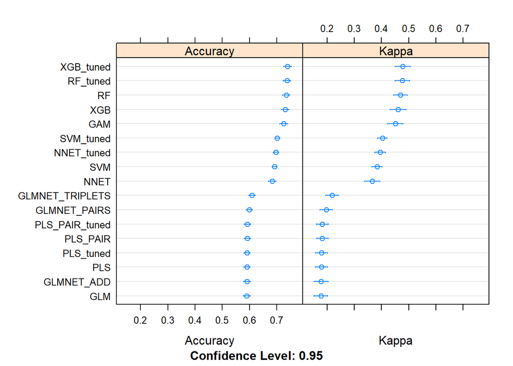

```r
all_models %>% resamples() %>% dotplot()
```

Plot Accuracy.

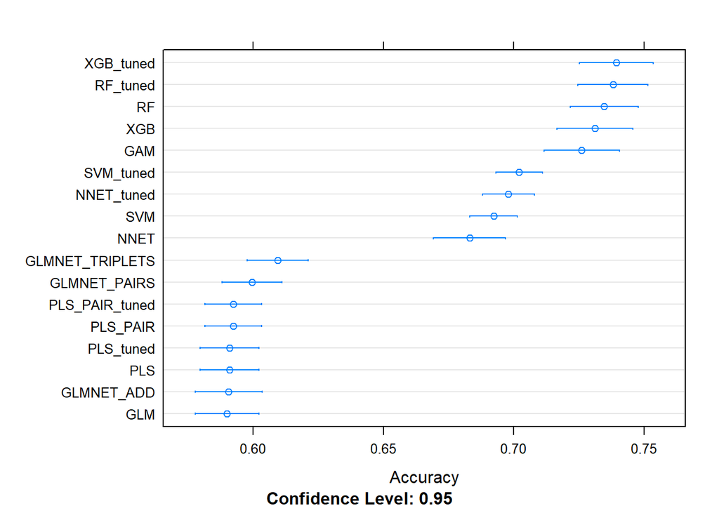

```r
all_models %>% resamples() %>% dotplot(metric = 'Accuracy')
```

##### Which model is the best?

Print Confusion Matrix for the best model.

```r
fit_xgb_tuned %>%  confusionMatrix.train()
```

```
## Cross-Validated (5 fold, repeated 3 times) Confusion Matrix
##
## (entries are percentual average cell counts across resamples)
##
##           Reference
## Prediction Fail Pass
##       Fail 34.8 11.9
##       Pass 14.1 39.1
##
##  Accuracy (average) : 0.7394
```

Print the best model.

```r
fit_xgb_tuned
```

```
## eXtreme Gradient Boosting
##
## 2013 samples
##   13 predictor
##    2 classes: 'Fail', 'Pass'
##
## No pre-processing
## Resampling: Cross-Validated (5 fold, repeated 3 times)
## Summary of sample sizes: 1611, 1610, 1610, 1611, 1610, 1610, ...
## Resampling results across tuning parameters:
##
##   eta  max_depth  nrounds  Accuracy   Kappa
##   0.1  1          10       0.6188141  0.2310605
##   0.1  1          20       0.6476221  0.2902525
##   0.1  1          30       0.6621989  0.3199662
##   0.1  1          40       0.6729673  0.3420509
##   0.1  1          50       0.6825632  0.3617927
##   0.1  2          10       0.6582209  0.3125661
##   0.1  2          20       0.6858750  0.3686934
##   0.1  2          30       0.6974589  0.3925685
##   0.1  2          40       0.7072347  0.4124307
##   0.1  2          50       0.7126975  0.4237355
##   0.1  3          10       0.6871992  0.3720727
##   0.1  3          20       0.7095515  0.4173165
##   0.1  3          30       0.7171718  0.4330096
##   0.1  3          40       0.7232975  0.4454747
##   0.1  3          50       0.7272644  0.4536715
##   0.1  4          10       0.7016024  0.4019063
##   0.1  4          20       0.7247876  0.4484904
##   0.1  4          30       0.7322379  0.4636067
##   0.1  4          40       0.7365427  0.4723097
##   0.1  4          50       0.7393541  0.4779767
##   0.1  5          10       0.7107087  0.4203016
##   0.1  5          20       0.7256122  0.4503649
##   0.1  5          30       0.7350493  0.4694119
##   0.1  5          40       0.7357155  0.4707580
##   0.1  5          50       0.7337288  0.4668348
##   0.1  6          10       0.7097177  0.4186230
##   0.1  6          20       0.7206466  0.4406727
##   0.1  6          30       0.7270998  0.4536450
```

[output cut: 208 more lines]

```
##   0.8  6          20       0.6933175  0.3860704
##   0.8  6          30       0.6954775  0.3903878
##   0.8  6          40       0.6994498  0.3983173
##   0.8  6          50       0.6931607  0.3856625
##
## Tuning parameter 'gamma' was held constant at a value of 0
## Tuning
##
## Tuning parameter 'min_child_weight' was held constant at a value of 1
##
## Tuning parameter 'subsample' was held constant at a value of 1
## Accuracy was used to select the optimal model using the largest value.
## The final values used for the model were nrounds = 50, max_depth = 4, eta
##  = 0.1, gamma = 0, colsample_bytree = 0.8, min_child_weight = 1 and subsample
##  = 1.
```

## Save the best model

```r
fit_xgb_tuned %>% readr::write_rds('mod_class_optionA_Accuracy_best.rds')
```